# Google Play Store Apps

## by Abdelrhman Khairy Werby

## Investigation Overview

Users download apps for various usage purposes. Given that paid service is usually better at offering a pleasant experience and that free apps are more accessible to everyone, what the dataset will tell us about that and on another questions like:

> 1- Free or paid apps have a higher rating?  
> 2- Which Apps Category mostly common on Google play store?  
> 3- Which apps Category has the highest rating? (with rating count > 5000)  
> 4- Which apps Category has the most number of installs?  
> 5- Which app Category has the largest size?

## Dataset Overview

> Google PlayStore App analytics. (1.1 Million + App Data).  
> The data collected with the help of Python and Scrapy running on a google cloud vm instance, The data was collected on December 2020.

## Free or paid apps have a higher rating?

The paid apps tend to have higher rating than free apps, because the paid apps mostly well designed apps in UI and UX so user give it high rating.

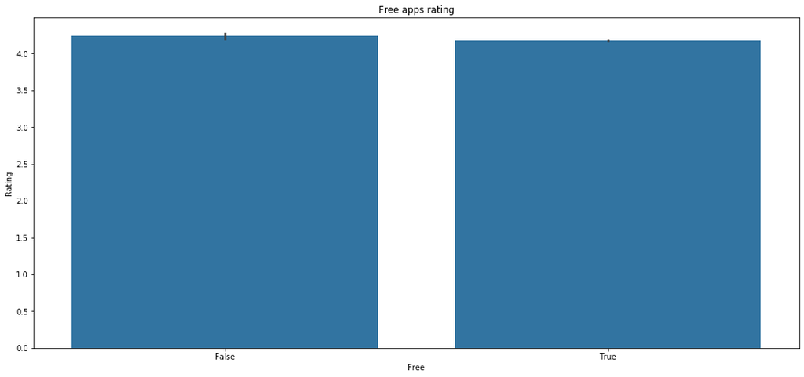

```python
# set plot size
plt.figure(figsize=(18, 8))
# set plot title
plt.title('Free apps rating')
# plot
sb.barplot(data=df_, x='Free', y='Rating', color=sb.color_palette()[0]);
```

## Which Apps Category mostly common on Google play store?

The Top 5 most common Category in Google play:

> 1- Education  
> 2- Music & Audio  
> 3- Entertainment  
> 4- Books & Reference  
> 5- Tools

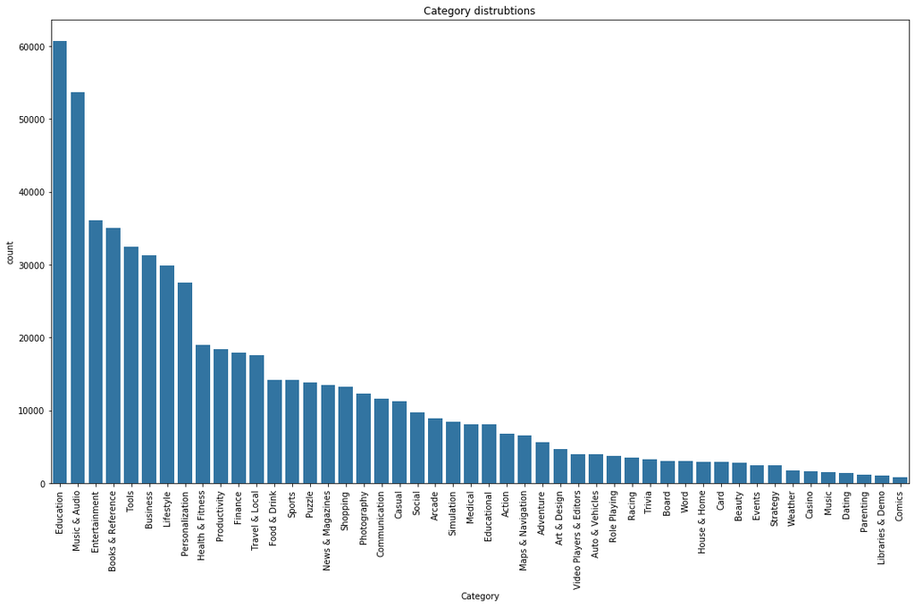

```python
bar_plot('Category distrubtions', 'Category', (18, 10), rotation=90)
```

## Which apps Category has the highest rating? (with rating count > 5000)

The bar plot shows the relationship between app category and the rating.  
NOTE: the plot may not be very accurate because the rating count varies from app to app (here I choose to plot only the apps with ratings above 5000 counts).

> 1- Books & Reference.  
> 2- Parenting.  
> 3- Health & Fitness.  
> 4- Word.  
> 5- Casino.

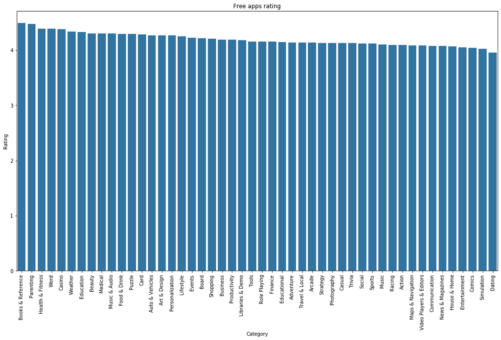

```python
bar_plot2d('Free apps rating', df_, 'Category', 'Rating', rotation=90)
```

## Which apps Category has the most number of installs?

The bar plot shows the relationship between app category and the number of installs of the app.  
The top 5 apps category in number of installs:

> 1- Racing.  
> 2- Action.  
> 3- Strategy.  
> 4- Arcade.  
> 5- Video Players & Editors

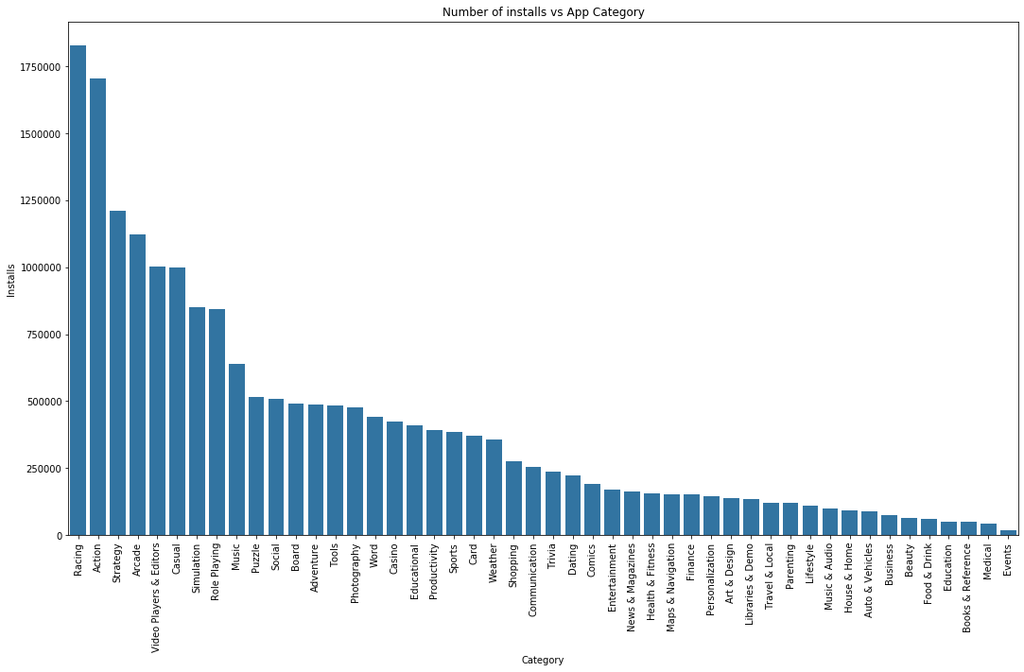

```python
bar_plot2d('Number of installs vs App Category', df, 'Category', 'Installs', rotation=90)
```

## Which app Category has the largest size?

The bar plot shows the relationship between the app category and the size of the app.  
The top 5 apps category in size:

> 1- Role Playing.  
> 2- Strategy.  
> 3- Simulation.  
> 4- Action.  
> 5- Racing.

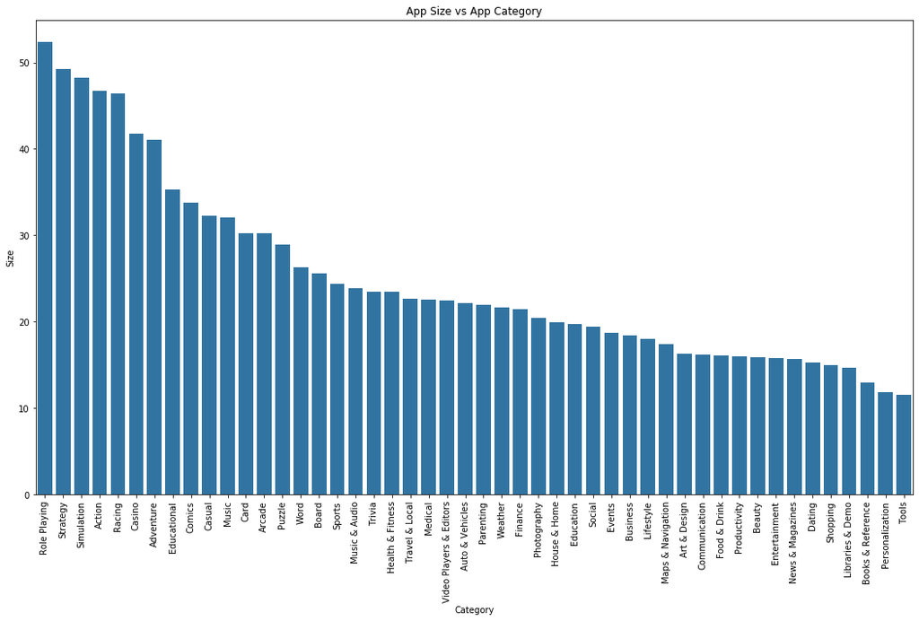

```python
bar_plot2d('App Size vs App Category', df, 'Category', 'Size', rotation=90)
```

```python
# jupyter nbconvert slide_deck_GooglePlay.ipynb --to slides --post serve --template output_toggle
```